# Twitter Sentiment Analysis

```python
import re #for regular expression
import nltk #for text manipulation
import string
import warnings
import numpy as np
import pandas as pd
import seaborn as sns
import matplotlib.pyplot as plt

pd.set_option("display.max_colwidth", 200)
warnings.filterwarnings("ignore", category=DeprecationWarning)

%matplotlib inline
```

```python
train = pd.read_csv('train_E6oV3lV.csv')
test = pd.read_csv('test_tweets_anuFYb8.csv')
```

Few non racist tweets

```python
train[train['label'] == 0].head(10)
```

|  | id | label | tweet |
| --- | --- | --- | --- |
| 0 | 1 | 0 | @user when a father is dysfunctional and is so selfish he drags his kids into his dysfunction. #run |
| 1 | 2 | 0 | @user @user thanks for #lyft credit i can't use cause they don't offer wheelchair vans in pdx. #disapointed #getthanked |
| 2 | 3 | 0 | bihday your majesty |
| 3 | 4 | 0 | #model i love u take with u all the time in urð±!!! ðððð ð¦ð¦ð¦ |
| 4 | 5 | 0 | factsguide: society now #motivation |
| 5 | 6 | 0 | [2/2] huge fan fare and big talking before they leave. chaos and pay disputes when they get there. #allshowandnogo |
| 6 | 7 | 0 | @user camping tomorrow @user @user @user @user @user @user @user dannyâ¦ |
| 7 | 8 | 0 | the next school year is the year for exams.ð¯ can't think about that ð #school #exams #hate #imagine #actorslife #revolutionschool #girl |
| 8 | 9 | 0 | we won!!! love the land!!! #allin #cavs #champions #cleveland #clevelandcavaliers â¦ |
| 9 | 10 | 0 | @user @user welcome here ! i'm it's so #gr8 ! |

Few racist tweets

```python
train[train['label'] == 1].head(10)
```

|  | id | label | tweet |
| --- | --- | --- | --- |
| 13 | 14 | 1 | @user #cnn calls #michigan middle school 'build the wall' chant '' #tcot |
| 14 | 15 | 1 | no comment! in #australia #opkillingbay #seashepherd #helpcovedolphins #thecove #helpcovedolphins |
| 17 | 18 | 1 | retweet if you agree! |
| 23 | 24 | 1 | @user @user lumpy says i am a . prove it lumpy. |
| 34 | 35 | 1 | it's unbelievable that in the 21st century we'd need something like this. again. #neverump #xenophobia |
| 56 | 57 | 1 | @user lets fight against #love #peace |
| 68 | 69 | 1 | ð©the white establishment can't have blk folx running around loving themselves and promoting our greatness |
| 77 | 78 | 1 | @user hey, white people: you can call people 'white' by @user #race #identity #medâ¦ |
| 82 | 83 | 1 | how the #altright uses &amp; insecurity to lure men into #whitesupremacy |
| 111 | 112 | 1 | @user i'm not interested in a #linguistics that doesn't address #race &amp; . racism is about #power. #raciolinguistics bringsâ¦ |

Dimensions of train & test dataset

```python
train.shape, test.shape
```

```
((31962, 3), (17197, 2))
```

Label distribution in the train dataset

```python
train["label"].value_counts()
```

```
0    29720
1     2242
Name: label, dtype: int64
```

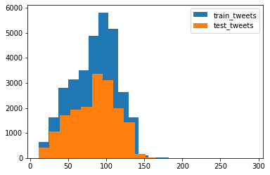

```python
length_train = train['tweet'].str.len()
length_test = test['tweet'].str.len()
plt.hist(length_train, bins=20, label="train_tweets")
plt.hist(length_test, bins=20, label="test_tweets")
plt.legend()
plt.show()
```

Combining the datasets to preprocess the data for convenience

```python
combi = train.append(test, ignore_index=True)
combi.shape
```

```
(49159, 3)
```

Removing unwanted text patterns from the tweets

```python
def remove_pattern(input_txt, pattern):
    r = re.findall(pattern, input_txt)
    for i in r:
        input_txt = re.sub(i, '', input_txt)
    return input_txt
```

Removing twitter handles and creating a new column "tidy_tweet"

```python
combi['tidy_tweet'] = np.vectorize(remove_pattern)(combi['tweet'], "@[\w]*")
combi.head()
```

|  | id | label | tweet | tidy_tweet |
| --- | --- | --- | --- | --- |
| 0 | 1 | 0.0 | @user when a father is dysfunctional and is so selfish he drags his kids into his dysfunction. #run | when a father is dysfunctional and is so selfish he drags his kids into his dysfunction. #run |
| 1 | 2 | 0.0 | @user @user thanks for #lyft credit i can't use cause they don't offer wheelchair vans in pdx. #disapointed #getthanked | thanks for #lyft credit i can't use cause they don't offer wheelchair vans in pdx. #disapointed #getthanked |
| 2 | 3 | 0.0 | bihday your majesty | bihday your majesty |
| 3 | 4 | 0.0 | #model i love u take with u all the time in urð±!!! ðððð ð¦ð¦ð¦ | #model i love u take with u all the time in urð±!!! ðððð ð¦ð¦ð¦ |
| 4 | 5 | 0.0 | factsguide: society now #motivation | factsguide: society now #motivation |

Removing punctuations, numbers, and special characters using regular expression “[^a-zA-Z#]” means anything except alphabets and ‘#’.

```python
combi['tidy_tweet'] = combi['tidy_tweet'].str.replace("[^a-zA-Z#]", " ")
combi.head(10)
```

|  | id | label | tweet | tidy_tweet |
| --- | --- | --- | --- | --- |
| 0 | 1 | 0.0 | @user when a father is dysfunctional and is so selfish he drags his kids into his dysfunction. #run | when a father is dysfunctional and is so selfish he drags his kids into his dysfunction #run |
| 1 | 2 | 0.0 | @user @user thanks for #lyft credit i can't use cause they don't offer wheelchair vans in pdx. #disapointed #getthanked | thanks for #lyft credit i can t use cause they don t offer wheelchair vans in pdx #disapointed #getthanked |
| 2 | 3 | 0.0 | bihday your majesty | bihday your majesty |
| 3 | 4 | 0.0 | #model i love u take with u all the time in urð±!!! ðððð ð¦ð¦ð¦ | #model i love u take with u all the time in ur |
| 4 | 5 | 0.0 | factsguide: society now #motivation | factsguide society now #motivation |
| 5 | 6 | 0.0 | [2/2] huge fan fare and big talking before they leave. chaos and pay disputes when they get there. #allshowandnogo | huge fan fare and big talking before they leave chaos and pay disputes when they get there #allshowandnogo |
| 6 | 7 | 0.0 | @user camping tomorrow @user @user @user @user @user @user @user dannyâ¦ | camping tomorrow danny |
| 7 | 8 | 0.0 | the next school year is the year for exams.ð¯ can't think about that ð #school #exams #hate #imagine #actorslife #revolutionschool #girl | the next school year is the year for exams can t think about that #school #exams #hate #imagine #actorslife #revolutionschool #girl |
| 8 | 9 | 0.0 | we won!!! love the land!!! #allin #cavs #champions #cleveland #clevelandcavaliers â¦ | we won love the land #allin #cavs #champions #cleveland #clevelandcavaliers |
| 9 | 10 | 0.0 | @user @user welcome here ! i'm it's so #gr8 ! | welcome here i m it s so #gr |

Removing short words, for example, terms like “hmm”, “oh” are of very little use.

```python
combi['tidy_tweet'] = combi['tidy_tweet'].apply(lambda x: ' '.join([w for w in x.split() if len(w)>3]))
```

```python
combi.head()
```

|  | id | label | tweet | tidy_tweet |
| --- | --- | --- | --- | --- |
| 0 | 1 | 0.0 | @user when a father is dysfunctional and is so selfish he drags his kids into his dysfunction. #run | when father dysfunctional selfish drags kids into dysfunction #run |
| 1 | 2 | 0.0 | @user @user thanks for #lyft credit i can't use cause they don't offer wheelchair vans in pdx. #disapointed #getthanked | thanks #lyft credit cause they offer wheelchair vans #disapointed #getthanked |
| 2 | 3 | 0.0 | bihday your majesty | bihday your majesty |
| 3 | 4 | 0.0 | #model i love u take with u all the time in urð±!!! ðððð ð¦ð¦ð¦ | #model love take with time |
| 4 | 5 | 0.0 | factsguide: society now #motivation | factsguide society #motivation |

Text Normalization, here we are using nltk’s PorterStemmer() function to normalize the tweets. But before that we will have to tokenize the tweets. Tokens are individual terms or words, and tokenization is the process of splitting a string of text into tokens.

```python
tokenized_tweet = combi['tidy_tweet'].apply(lambda x: x.split())
tokenized_tweet.head()
```

```
0                [when, father, dysfunctional, selfish, drags, kids, into, dysfunction, #run]
1    [thanks, #lyft, credit, cause, they, offer, wheelchair, vans, #disapointed, #getthanked]
2                                                                     [bihday, your, majesty]
3                                                            [#model, love, take, with, time]
4                                                          [factsguide, society, #motivation]
Name: tidy_tweet, dtype: object
```

Now we can normalize the tokenized tweets.

```python
from nltk.stem.porter import *
stemmer = PorterStemmer()
tokenized_tweet = tokenized_tweet.apply(lambda x: [stemmer.stem(i) for i in x])

# Stemming
```

```python
for i in range(len(tokenized_tweet)):
    tokenized_tweet[i] = ' '.join(tokenized_tweet[i])
combi['tidy_tweet'] = tokenized_tweet
```

Visualizing all the words in our data using the Wordcloud plot.

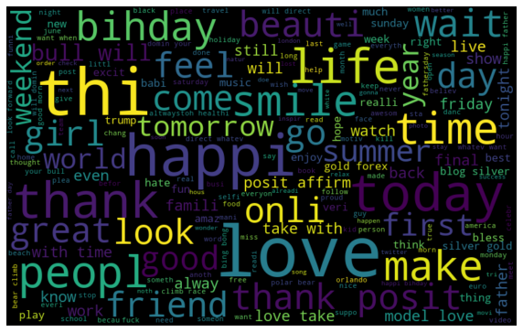

```python
all_words = ' '.join([text for text in combi['tidy_tweet']])
from wordcloud import WordCloud
wordcloud = WordCloud(width=800, height=500, random_state=21, max_font_size=110).generate(all_words)
plt.figure(figsize=(10, 7))
plt.imshow(wordcloud, interpolation="bilinear")
plt.axis('off')
plt.show()
```

Words in non racist tweets.

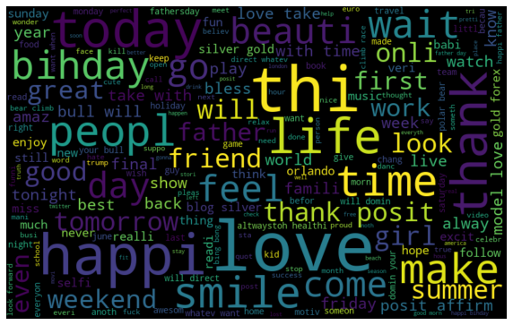

```python
normal_words =' '.join([text for text in combi['tidy_tweet'][combi['label'] == 0]])
wordcloud = WordCloud(width=800, height=500, random_state=21, max_font_size=110).generate(normal_words)
plt.figure(figsize=(10,7))
plt.imshow(wordcloud, interpolation='bilinear')
plt.axis('off')
plt.show()
```

Racist tweets.

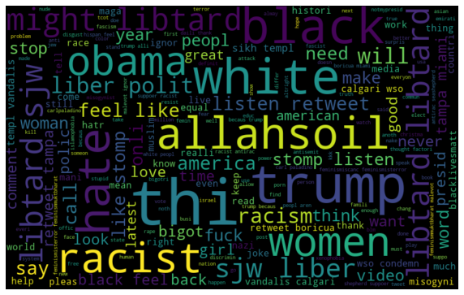

```python
negative_words = ' '.join([text for text in combi['tidy_tweet'][combi['label'] == 1]])
wordcloud = WordCloud(width=800, height=500, random_state=21, max_font_size=110).generate(negative_words)
plt.figure(figsize=(10,7))
plt.imshow(wordcloud, interpolation='bilinear')
plt.axis('off')
plt.show()
```

The impact of Hashtags on tweets sentiment.

```python
def hashtag_extract(x):
    hashtags = []    # Loop over the words in the tweet
    for i in x:
        ht = re.findall(r"#(\w+)", i)
        hashtags.append(ht)
        return hashtags
```

```python
# extracting hashtags from non racist/sexist tweets
HT_regular = hashtag_extract(combi['tidy_tweet'][combi['label'] == 0])
# extracting hashtags from racist/sexist tweets
HT_negative = hashtag_extract(combi['tidy_tweet'][combi['label'] == 1])
# unnesting list
HT_regular = sum(HT_regular,[])
HT_negative = sum(HT_negative,[])
```

Plotting top 'n' hashtags - non-racist tweets.

[figure not shown]

```python
a = nltk.FreqDist(HT_regular)
d = pd.DataFrame({'Hashtag': list(a.keys()), 'Count': list(a.values())})
# selecting top 20 most frequent hashtags
d = d.nlargest(columns = "Count", n = 20)
plt.figure(figsize = (16, 5))
ax = sns.barplot(data = d, x = "Hashtag", y = "Count")
ax.set(ylabel = 'Count')
plt.show()
```

[figure not shown]

```python
b = nltk.FreqDist(HT_regular)
e = pd.DataFrame({'Hashtag': list(b.keys()), 'Count': list(b.values())})
# selecting top 20 most frequent hashtags
e = e.nlargest(columns = "Count", n = 20)
plt.figure(figsize = (16, 5))
ax = sns.barplot(data = e, x = "Hashtag", y = "Count")
```

Bag-of-Words Features

```python
from sklearn.feature_extraction.text import TfidfVectorizer, CountVectorizer
import gensim
```

```python
bow_vectorizer = CountVectorizer(max_df=0.90, min_df=2, max_features=1000,
                                stop_words='english')
bow = bow_vectorizer.fit_transform(combi['tidy_tweet'])
bow.shape
```

```
(49159, 1000)
```

TF-IDF Features

```python
tfidf_vectorizer = TfidfVectorizer(max_df=0.90, min_df=2, max_features=1000, stop_words='english')
tfidf = tfidf_vectorizer.fit_transform(combi['tidy_tweet'])
tfidf.shape
```

```
(49159, 1000)
```

Word2Vec

```python
tokenized_tweet = combi['tidy_tweet'].apply(lambda x: x.split())  #tokenizing
model_w2v = gensim.models.Word2Vec(tokenized_tweet, size=200, window=5, min_count=2, sg=1, hs=0, negative=10, workers=2, seed=34)
```

```python
model_w2v.train(tokenized_tweet, total_examples= len(combi['tidy_tweet']), epochs=20)
```

```
(6510028, 7536020)
```

```python
model_w2v.wv.most_similar(positive="dinner")
```

```
[('#avocado', 0.5631513595581055),
 ('spaghetti', 0.5552595853805542),
 ('cookout', 0.5472978353500366),
 ('#bihdaydinn', 0.5431941747665405),
 ('fav', 0.5396216511726379),
 ('#biall', 0.5382127165794373),
 ('noodl', 0.5381280183792114),
 ('melani', 0.53731369972229),
 ('#foodcoma', 0.5366406440734863),
 ('#cellar', 0.5353344678878784)]
```

```python
model_w2v.wv.most_similar(positive="trump")
```

```
[('donald', 0.5610439777374268),
 ('hillari', 0.558605968952179),
 ('phoni', 0.5329411029815674),
 ('#delegaterevolt', 0.5182048082351685),
 ('unstabl', 0.5160995721817017),
 ('unfit', 0.5147356986999512),
 ('endors', 0.5142834782600403),
 ('unfavor', 0.5121932029724121),
 ('melo', 0.5121713876724243),
 ('potu', 0.5101584196090698)]
```

Vector representation of any word from our corpus.

```python
model_w2v['food']
```

```
array([-0.12284572,  0.29897505,  0.6282495 ,  0.04666168,  0.27591395,
       -0.25272128, -0.10929587, -0.12765813, -0.6726799 , -0.14327411,
        0.14145617,  0.06102759, -0.24092272, -1.1393566 , -0.78144616,
       -0.3379462 ,  0.8116342 , -0.6932882 , -0.2481351 , -0.20571011,
       -0.21351193,  0.05494193,  0.1134215 , -0.42791495,  0.59959173,
        1.08728   ,  0.36233065, -0.5643268 ,  1.0859654 ,  0.04277683,
        0.2826427 , -0.9403344 ,  1.0361197 , -0.47518831,  0.3546031 ,
       -0.08767244,  0.4599168 , -0.49324355, -0.14457972, -0.35251644,
       -0.3663303 ,  0.8397754 ,  0.01190213,  0.37896946,  0.1241968 ,
        0.1780396 ,  0.39484754,  0.10542063,  0.8246051 , -0.02183156,
        0.32454616,  0.13012847,  0.231147  ,  0.8772261 , -0.41711164,
        0.3274168 , -0.37628806,  0.00924249, -0.1617558 ,  0.20810103,
       -0.01021142,  0.25785413,  0.30267295, -0.03829791,  0.1702399 ,
        0.36939093,  0.19605741,  0.01527771,  0.49782977,  0.50971776,
       -0.35511294, -0.11182649,  0.4087064 ,  0.17790774, -0.03828233,
        0.26130962, -0.23147136, -0.11295119,  0.39945233, -0.27413413,
       -0.2701397 , -0.13182266,  0.38962966,  0.3565337 ,  0.02386497,
       -0.24060628, -0.02968258,  0.2527334 , -0.588373  ,  0.5045123 ,
        0.81231916,  0.05327739, -0.24367464, -0.5295391 , -0.30880156,
        0.71984667, -0.33693552,  0.144203  , -0.6734509 , -0.59095293,
        0.08218697, -0.2925784 , -0.9576465 , -0.55457914, -0.10667592,
       -0.11090855, -0.46754426, -0.22115889,  0.65883   ,  0.32752475,
       -0.6901127 ,  0.642965  , -0.18169005, -0.3264508 , -0.18705311,
       -0.21201701, -0.57717663,  0.08244924,  0.1931466 ,  0.65335256,
       -0.10526749,  0.7829219 ,  0.5561678 ,  0.30218717, -0.580023  ,
        0.23972493,  0.3294171 , -0.6182795 ,  0.27671397, -0.2192486 ,
        0.25721696, -0.23358336, -0.04334998,  0.41690606,  0.17797665,
       -0.45654947, -1.13704   ,  0.59130126,  0.20149605,  0.00349257,
       -0.15827115, -0.00215837, -0.19354236,  0.12882377, -0.2257442 ,
        0.30983555, -0.6159266 ,  0.06017859, -0.9744468 ,  0.47908846,
        0.2836254 , -0.84162474,  0.27622685, -0.868027  , -0.35019407,
       -0.36347514,  0.26583606,  0.70152247,  0.084145  ,  0.11505242,
       -0.12430768, -0.61133087,  0.20324126, -0.36249176, -0.00341899,
        0.5153335 , -0.43320534,  0.24936704,  0.07174534, -0.16732675,
        0.14536792,  0.55427575, -0.00809094, -0.41315386, -0.0868823 ,
        0.9138121 ,  0.01228541,  0.36450952,  0.30521205,  0.12675107,
       -0.35676965, -0.16220322, -0.5217292 ,  0.3811024 , -0.25466782,
       -0.36856285,  0.6908982 , -0.18357387, -0.19480175, -0.13489176,
       -0.3603986 ,  0.41300878,  0.18786621,  0.4601949 , -0.20257792,
       -0.32679492, -0.2570452 ,  0.50590825,  0.7896365 , -0.3019271 ],
      dtype=float32)
```

```python
len(model_w2v['food']) #The length of the vector is 200
```

```
200
```

Function to create a vector for each tweet by taking the average of the vectors of the words present in the tweet.

```python
def word_vector(tokens, size):
    vec = np.zeros(size).reshape((1, size))
    count = 0
    for word in tokens:
        try:
            vec += model_w2v[word].reshape((1, size))
            count += 1.
        except KeyError: # handling the case where the token is not in vocabulary
                        continue
    if count != 0:
        vec /= count
    return vec
```

Preparing word2vec feature set.

```python
wordvec_arrays = np.zeros((len(tokenized_tweet), 200))
for i in range(len(tokenized_tweet)):
    wordvec_arrays[i, :] = word_vector(tokenized_tweet[i], 200)
    wordvec_df = pd.DataFrame(wordvec_arrays)
wordvec_df.shape

# Now we have 200 new features, whereas in Bag of Words and TF-IDF we had 1000 features.
```

```
(49159, 200)
```

Doc2Vec embedding.

```python
from tqdm import tqdm
tqdm.pandas(desc="progress-bar")
from gensim.models.doc2vec import LabeledSentence

# To implement doc2vec, we have to labelise or tag each tokenised tweet with unique IDs.
# We can do so by using Gensim’s LabeledSentence() function.
```

```python
def add_label(twt):
    output =[]
    for i, s in zip(twt.index, twt):
        output.append(LabeledSentence(s, ["tweet_" + str(i)]))
    return output

labeled_tweets = add_label(tokenized_tweet)  # label all the tweets
```

```python
labeled_tweets[:6]
```

```
[LabeledSentence(words=['when', 'father', 'dysfunct', 'selfish', 'drag', 'kid', 'into', 'dysfunct', '#run'], tags=['tweet_0']),
 LabeledSentence(words=['thank', '#lyft', 'credit', 'caus', 'they', 'offer', 'wheelchair', 'van', '#disapoint', '#getthank'], tags=['tweet_1']),
 LabeledSentence(words=['bihday', 'your', 'majesti'], tags=['tweet_2']),
 LabeledSentence(words=['#model', 'love', 'take', 'with', 'time'], tags=['tweet_3']),
 LabeledSentence(words=['factsguid', 'societi', '#motiv'], tags=['tweet_4']),
 LabeledSentence(words=['huge', 'fare', 'talk', 'befor', 'they', 'leav', 'chao', 'disput', 'when', 'they', 'there', '#allshowandnogo'], tags=['tweet_5'])]
```

Train a doc2vec model.

```python
model_d2v = gensim.models.Doc2Vec(dm=1, dm_mean=1, size=200, window=5, negative=7,
                                  min_count=5, workers=3, alpha=0.1, seed=23)
model_d2v.build_vocab([i for i in tqdm(labeled_tweets)])

model_d2v.train(labeled_tweets, total_examples= len(combi['tidy_tweet']), epochs=15)
```

Preparing doc2vec feature set.

```python
docvec_arrays = np.zeros((len(tokenized_tweet), 200))
for i in range(len(combi)):
    docvec_arrays[i,:] = model_d2v.docvecs[i].reshape((1,200))

docvec_df = pd.DataFrame(docvec_arrays)
docvec_df.shape
```

```
(49159, 200)
```

# Modeling

Logistic Regression.

```python
from sklearn.linear_model import LogisticRegression
from sklearn.model_selection import train_test_split
from sklearn.metrics import f1_score
```

Bag-of-Words Features - Firstly trying to fit the logistic regression model on the Bag-of_Words (BoW) features.

```python
#Extracting train and test BoW features

train_bow = bow[:31962,:]
test_bow = bow[31962:,:]

#splitting data into training and validation set

xtrain_bow, xvalid_bow, ytrain, yvalid = train_test_split(train_bow, train['label'], random_state=42, test_size=0.3)
lreg = LogisticRegression()

#training the model

lreg.fit(xtrain_bow, ytrain)
prediction = lreg.predict_proba(xvalid_bow)

#predicting on the validation set

prediction_int = prediction[:,1] >= 0.3

#if prediction is greater than or equal to 0.3 than 1 else 0

prediction_int = prediction_int.astype(np.int)
f1_score(yvalid, prediction_int)

#calculating f1 score for the validation set
```

```
0.5303408146300915
```

Making predictions for the test dataset and create a submission file.

```python
test_pred = lreg.predict_proba(test_bow)
test_pred_int = test_pred[:,1] >= 0.3
test_pred_int = test_pred_int.astype(np.int)
test['label'] = test_pred_int
submission = test[['id','label']]
submission.to_csv('sub_lreg_bow.csv', index=False)

#writing data to a CSV file
```

TF-IDF Features - following the same steps as above, but now for the TF-IDF feature set.

```python
train_tfidf = tfidf[:31962,:]
test_tfidf = tfidf[31962:,:]
xtrain_tfidf = train_tfidf[ytrain.index]
xvalid_tfidf = train_tfidf[yvalid.index]

lreg.fit(xtrain_tfidf, ytrain)
prediction = lreg.predict_proba(xvalid_tfidf)
prediction_int = prediction[:,1] >= 0.3
prediction_int = prediction_int.astype(np.int)
f1_score(yvalid, prediction_int)

#calculating f1 score for the validation set

#Public Leaderboard F1 score is 0.564
```

```
0.5451327433628319
```

Word2Vec Features

```python
train_w2v = wordvec_df.iloc[:31962,:]
test_w2v = wordvec_df.iloc[31962:,:]
xtrain_w2v = train_w2v.iloc[ytrain.index,:]
xvalid_w2v = train_w2v.iloc[yvalid.index,:]

lreg.fit(xtrain_w2v, ytrain)
prediction = lreg.predict_proba(xvalid_w2v)
prediction_int = prediction[:,1] >= 0.3
prediction_int = prediction_int.astype(np.int)
f1_score(yvalid, prediction_int)

#Public Leaderboard F1 score is 0.661
```

```
0.617910447761194
```

Doc2Vec Features

```python
train_d2v = docvec_df.iloc[:31962,:]
test_d2v = docvec_df.iloc[31962:,:]
xtrain_d2v = train_d2v.iloc[ytrain.index,:]
xvalid_d2v = train_d2v.iloc[yvalid.index,:]

lreg.fit(xtrain_d2v, ytrain)
prediction = lreg.predict_proba(xvalid_d2v)
prediction_int = prediction[:,1] >= 0.3
prediction_int = prediction_int.astype(np.int)
f1_score(yvalid, prediction_int)

#Public Leaderboard F1 score is 0.381
```

```
0.39489361702127657
```

Support Vector Machine (SVM)

```python
from sklearn import svm
```

Bag-of-Words Features

```python
svc = svm.SVC(kernel='linear', C=1, probability=True).fit(xtrain_bow, ytrain)
prediction = svc.predict_proba(xvalid_bow)
prediction_int = prediction[:,1] >= 0.3
prediction_int = prediction_int.astype(np.int)
f1_score(yvalid, prediction_int)
```

```
0.5092936802973977
```

```python
# predictions for the test dataset and create another submission file.

test_pred = svc.predict_proba(test_bow)
test_pred_int = test_pred[:,1] >= 0.3
test_pred_int = test_pred_int.astype(np.int)
test['label'] = test_pred_int
submission = test[['id','label']]
submission.to_csv('sub_svm_bow.csv', index=False)

# Public leaderboard F1 score: 0.554
# Both validation score and leaderboard score are slightly lesser than
# the Logistic Regression scores for bag-of-words features.
```

TF-IDF Features

```python
svc = svm.SVC(kernel='linear',
C=1, probability=True).fit(xtrain_tfidf, ytrain)
prediction = svc.predict_proba(xvalid_tfidf)
prediction_int = prediction[:,1] >= 0.3
prediction_int = prediction_int.astype(np.int)
f1_score(yvalid, prediction_int)

# Public leaderboard F1 score: 0.546
```

```
0.5104831358249772
```

Word2Vec Features

```python
svc = svm.SVC(kernel='linear', C=1, probability=True).fit(xtrain_w2v, ytrain)
prediction = svc.predict_proba(xvalid_w2v)
prediction_int = prediction[:,1] >= 0.3
prediction_int = prediction_int.astype(np.int)
f1_score(yvalid, prediction_int)

# Public Leaderboard F1 Score: 0.654
```

```
0.6115444617784712
```

Doc2Vec Features

```python
svc = svm.SVC(kernel='linear', C=1, probability=True).fit(xtrain_d2v, ytrain)
prediction = svc.predict_proba(xvalid_d2v)
prediction_int = prediction[:,1] >= 0.3
prediction_int = prediction_int.astype(np.int)
f1_score(yvalid, prediction_int)

# Public Leaderboard F1 Score: 0.214
```

```
0.2277339346110485
```

Random Forest

```python
from sklearn.ensemble import RandomForestClassifier
```

Bag-of-Words Features

```python
# Training our RandomForest model on the Bag-of-Words features and check its
# performance on both validation set and public leaderboard.

rf = RandomForestClassifier(n_estimators=400, random_state=11).fit(xtrain_bow, ytrain)
prediction = rf.predict(xvalid_bow)
f1_score(yvalid, prediction)
```

```
0.5529225908372828
```

```python
# Predictions for the test dataset and create another submission file.

test_pred = rf.predict(test_bow)
test['label'] = test_pred
submission = test[['id','label']]
submission.to_csv('sub_rf_bow.csv', index=False)

# Public Leaderboard F1 Score: 0.598
```

TF-IDF Features

```python
rf = RandomForestClassifier(n_estimators=400, random_state=11).fit(xtrain_tfidf, ytrain)
prediction = rf.predict(xvalid_tfidf)
f1_score(yvalid, prediction)

# Public Leaderboard F1 Score: 0.589
```

```
0.562152133580705
```

Word2Vec Features

```python
rf = RandomForestClassifier(n_estimators=400, random_state=11).fit(xtrain_w2v, ytrain)
prediction = rf.predict(xvalid_w2v)
f1_score(yvalid, prediction)

# Public Leaderboard F1 Score: 0.549
```

```
0.4890829694323144
```

Doc2Vec Features

```python
rf = RandomForestClassifier(n_estimators=400, random_state=11).fit(xtrain_d2v, ytrain)
prediction = rf.predict(xvalid_d2v)
f1_score(yvalid, prediction)

# Public Leaderboard F1 Score: 0.07
```

```
0.06497175141242938
```

Extreme Gradient Boosting (XGBoost)

```python
from xgboost import XGBClassifier
```

Bag-of-Words Features

```python
xgb_model = XGBClassifier(max_depth=6, n_estimators=1000).fit(xtrain_bow, ytrain)
prediction = xgb_model.predict(xvalid_bow)
f1_score(yvalid, prediction)
```

```
0.5247706422018349
```

```python
test_pred = xgb_model.predict(test_bow)
test['label'] = test_pred
submission = test[['id','label']]
submission.to_csv('sub_xgb_bow.csv', index=False)

# Public Leaderboard F1 Score: 0.554
```

TF-IDF Features

```python
xgb = XGBClassifier(max_depth=6, n_estimators=1000).fit(xtrain_tfidf, ytrain)
prediction = xgb.predict(xvalid_tfidf)
f1_score(yvalid, prediction)

# Public Leaderboard F1 Score: 0.554
```

```
0.5394265232974911
```

Word2Vec Features

```python
xgb = XGBClassifier(max_depth=6, n_estimators=1000, nthread= 3).fit(xtrain_w2v, ytrain)
prediction = xgb.predict(xvalid_w2v)
f1_score(yvalid, prediction)

# Public Leaderboard F1 Score: 0.698

# Hence XGBoost model on word2vec features has outperformed
# all the previuos models.
```

```
0.6476360392506691
```

Doc2Vec Features

```python
xgb = XGBClassifier(max_depth=6, n_estimators=1000, nthread= 3).fit(xtrain_d2v, ytrain)
prediction = xgb.predict(xvalid_d2v)
f1_score(yvalid, prediction)

# Public Leaderboard F1 Score: 0.374
```

```
0.3551609322974473
```

```python
import xgboost as xgb
```

```python
# Using DMatrices, since it contains both the features and the target.

dtrain = xgb.DMatrix(xtrain_w2v, label=ytrain)
dvalid = xgb.DMatrix(xvalid_w2v, label=yvalid)
dtest = xgb.DMatrix(test_w2v)
```

```python
# Parameters that we are going to tune

params = {
    'objective':'binary:logistic',
    'max_depth':6,
    'min_child_weight': 1,
    'eta':.3,
    'subsample': 1,
    'colsample_bytree': 1
 }
```

```python
# Preparing a custom evaluation metric to calculate F1 score.

def custom_eval(preds, dtrain):
    labels = dtrain.get_label().astype(np.int)
    preds = (preds >= 0.3).astype(np.int)
    return [('f1_score', f1_score(labels, preds))]
```

Tuning max_depth and min_child_weight

```python
gridsearch_params = [
    (max_depth, min_child_weight)
    for max_depth in range(6,10)
     for min_child_weight in range(5,8)
 ]
```

```python
max_f1 = 0. # initializing with 0
best_params = None
for max_depth, min_child_weight in gridsearch_params:
    print("CV with max_depth={}, min_child_weight={}".format(
                             max_depth,
                             min_child_weight))
```

```
CV with max_depth=6, min_child_weight=5
CV with max_depth=6, min_child_weight=6
CV with max_depth=6, min_child_weight=7
CV with max_depth=7, min_child_weight=5
CV with max_depth=7, min_child_weight=6
CV with max_depth=7, min_child_weight=7
CV with max_depth=8, min_child_weight=5
CV with max_depth=8, min_child_weight=6
CV with max_depth=8, min_child_weight=7
CV with max_depth=9, min_child_weight=5
CV with max_depth=9, min_child_weight=6
CV with max_depth=9, min_child_weight=7
```

```python
# Update the parameters

params['max_depth'] = max_depth
params['min_child_weight'] = min_child_weight
```

```python
# Cross-validation

cv_results = xgb.cv(params, dtrain, feval= custom_eval, num_boost_round=200, maximize=True, seed=16, nfold=5, early_stopping_rounds=10)
```

```python
# Finding best F1 Score

mean_f1 = cv_results['test-f1_score-mean'].max()
```

```python
boost_rounds = cv_results['test-f1_score-mean'].argmax()
print("\tF1 Score {} for {} rounds".format(mean_f1, boost_rounds))
if mean_f1 > max_f1:
        max_f1 = mean_f1
        best_params = (max_depth,min_child_weight)
```

```
	F1 Score 0.6732116 for 38 rounds
```

```python
print("Best params: {}, {}, F1 Score: {}".format(best_params[0], best_params[1], max_f1))
```

```
Best params: 9, 7, F1 Score: 0.6732116
```

Updating max_depth and min_child_weight parameters.

```python
params['max_depth'] = 8
params['min_child_weight'] = 6
```

Tuning subsample and colsample

```python
gridsearch_params = [
    (subsample, colsample)
    for subsample in [i/10. for i in range(5,10)]
    for colsample in [i/10. for i in range(5,10)] ]
```

```python
max_f1 = 0.
best_params = None
for subsample, colsample in gridsearch_params:
    print("CV with subsample={}, colsample={}".format(
                             subsample,
                             colsample))
```

```
CV with subsample=0.5, colsample=0.5
CV with subsample=0.5, colsample=0.6
CV with subsample=0.5, colsample=0.7
CV with subsample=0.5, colsample=0.8
CV with subsample=0.5, colsample=0.9
CV with subsample=0.6, colsample=0.5
CV with subsample=0.6, colsample=0.6
CV with subsample=0.6, colsample=0.7
CV with subsample=0.6, colsample=0.8
CV with subsample=0.6, colsample=0.9
CV with subsample=0.7, colsample=0.5
CV with subsample=0.7, colsample=0.6
CV with subsample=0.7, colsample=0.7
CV with subsample=0.7, colsample=0.8
CV with subsample=0.7, colsample=0.9
CV with subsample=0.8, colsample=0.5
CV with subsample=0.8, colsample=0.6
CV with subsample=0.8, colsample=0.7
CV with subsample=0.8, colsample=0.8
CV with subsample=0.8, colsample=0.9
CV with subsample=0.9, colsample=0.5
CV with subsample=0.9, colsample=0.6
CV with subsample=0.9, colsample=0.7
CV with subsample=0.9, colsample=0.8
CV with subsample=0.9, colsample=0.9
```

```python
# Update our parameters

params['colsample'] = colsample
params['subsample'] = subsample
cv_results = xgb.cv(params, dtrain, feval= custom_eval, num_boost_round=200, maximize=True, seed=16, nfold=5, early_stopping_rounds=10)
```

[output not shown]

```python
# Finding best F1 Score

mean_f1 = cv_results['test-f1_score-mean'].max()
boost_rounds = cv_results['test-f1_score-mean'].argmax()
print("\tF1 Score {} for {} rounds".format(mean_f1, boost_rounds))
if mean_f1 > max_f1:
        max_f1 = mean_f1
        best_params = (subsample, colsample)
```

```
	F1 Score 0.668812 for 33 rounds
```

```python
print("Best params: {}, {}, F1 Score: {}".format(best_params[0], best_params[1], max_f1))
```

```
Best params: 0.9, 0.9, F1 Score: 0.668812
```

Updating subsample and colsample_bytree

```python
params['subsample'] = .9
params['colsample_bytree'] = .5
```

Tuning the learning rate.

```python
max_f1 = 0.
best_params = None
for eta in [.3, .2, .1, .05, .01, .005]:
    print("CV with eta={}".format(eta))
     # Update ETA
params['eta'] = eta
```

```
CV with eta=0.3
CV with eta=0.2
CV with eta=0.1
CV with eta=0.05
CV with eta=0.01
CV with eta=0.005
```

```python
cv_results = xgb.cv(params, dtrain, feval= custom_eval, num_boost_round=1000, maximize=True, seed=16, nfold=5, early_stopping_rounds=20)
```

[output not shown]

```python
# Finding best F1 Score

mean_f1 = cv_results['test-f1_score-mean'].max()
boost_rounds = cv_results['test-f1_score-mean'].argmax()
print("\tF1 Score {} for {} rounds".format(mean_f1, boost_rounds))
if mean_f1 > max_f1:
        max_f1 = mean_f1
        best_params = eta
print("Best params: {}, F1 Score: {}".format(best_params, max_f1))
```

```
	F1 Score 0.1302024 for 0 rounds
Best params: 0.005, F1 Score: 0.1302024
```

```python
params['eta'] = .1
```

The final list of tuned parameters.

```python
params
{'colsample': 0.9,
 'colsample_bytree': 0.5, 'eta': 0.1,
 'max_depth': 8, 'min_child_weight': 6,
 'objective': 'binary:logistic',
 'subsample': 0.9}
```

```
{'colsample': 0.9,
 'colsample_bytree': 0.5,
 'eta': 0.1,
 'max_depth': 8,
 'min_child_weight': 6,
 'objective': 'binary:logistic',
 'subsample': 0.9}
```

```python
xgb_model = xgb.train(params, dtrain, feval=custom_eval, num_boost_round= 1000, maximize=True, evals=[(dvalid, "Validation")], early_stopping_rounds=10)
```

```
[11:37:30] WARNING: C:\Users\Administrator\workspace\xgboost-win64_release_1.1.0\src\learner.cc:480:
Parameters: { colsample } might not be used.

  This may not be accurate due to some parameters are only used in language bindings but
  passed down to XGBoost core.  Or some parameters are not used but slip through this
  verification. Please open an issue if you find above cases.


[0]	Validation-error:0.06236	Validation-f1_score:0.13317
Multiple eval metrics have been passed: 'Validation-f1_score' will be used for early stopping.

Will train until Validation-f1_score hasn't improved in 10 rounds.
[1]	Validation-error:0.05715	Validation-f1_score:0.13317
[2]	Validation-error:0.05517	Validation-f1_score:0.13317
[3]	Validation-error:0.05444	Validation-f1_score:0.13317
[4]	Validation-error:0.05360	Validation-f1_score:0.13317
[5]	Validation-error:0.05381	Validation-f1_score:0.35480
[6]	Validation-error:0.05402	Validation-f1_score:0.46486
[7]	Validation-error:0.05433	Validation-f1_score:0.52386
[8]	Validation-error:0.05256	Validation-f1_score:0.56669
[9]	Validation-error:0.05298	Validation-f1_score:0.58129
[10]	Validation-error:0.05235	Validation-f1_score:0.59072
[11]	Validation-error:0.05141	Validation-f1_score:0.59812
[12]	Validation-error:0.05141	Validation-f1_score:0.60656
[13]	Validation-error:0.05079	Validation-f1_score:0.60876
[14]	Validation-error:0.05110	Validation-f1_score:0.61098
[15]	Validation-error:0.05079	Validation-f1_score:0.61186
[16]	Validation-error:0.04954	Validation-f1_score:0.61798
[17]	Validation-error:0.04891	Validation-f1_score:0.61241
[18]	Validation-error:0.04901	Validation-f1_score:0.61075
[19]	Validation-error:0.04943	Validation-f1_score:0.61589
[20]	Validation-error:0.04901	Validation-f1_score:0.61006
[21]	Validation-error:0.04912	Validation-f1_score:0.61551
[22]	Validation-error:0.04881	Validation-f1_score:0.61718
[23]	Validation-error:0.04891	Validation-f1_score:0.61629
[24]	Validation-error:0.04870	Validation-f1_score:0.62416
[25]	Validation-error:0.04828	Validation-f1_score:0.62353
[26]	Validation-error:0.04828	Validation-f1_score:0.61668
[27]	Validation-error:0.04839	Validation-f1_score:0.61965
[28]	Validation-error:0.04755	Validation-f1_score:0.62121
```

[output cut: 15 more lines]

```
[44]	Validation-error:0.04620	Validation-f1_score:0.63342
[45]	Validation-error:0.04578	Validation-f1_score:0.63394
[46]	Validation-error:0.04599	Validation-f1_score:0.63621
[47]	Validation-error:0.04609	Validation-f1_score:0.63561
[48]	Validation-error:0.04620	Validation-f1_score:0.63297
[49]	Validation-error:0.04651	Validation-f1_score:0.63516
[50]	Validation-error:0.04609	Validation-f1_score:0.62843
[51]	Validation-error:0.04578	Validation-f1_score:0.63175
[52]	Validation-error:0.04630	Validation-f1_score:0.63358
[53]	Validation-error:0.04589	Validation-f1_score:0.63402
[54]	Validation-error:0.04557	Validation-f1_score:0.63184
[55]	Validation-error:0.04516	Validation-f1_score:0.63411
[56]	Validation-error:0.04516	Validation-f1_score:0.63253
Stopping. Best iteration:
[46]	Validation-error:0.04599	Validation-f1_score:0.63621
```

```python
# Final submission file.

test_pred = xgb_model.predict(dtest)
test['label'] = (test_pred >= 0.3).astype(np.int)
submission = test[['id','label']]
submission.to_csv('sub_xgb_w2v_finetuned.csv', index=False)

# Public Leaderboard F1 Score: 0.703
```

The tuning worked, this is the best score on the public leaderboard.